# RR Project Report

2023-06-18

Yelyzaveta Nemchynova Elvin Shirinov Kathryn Nagiel

## Introduction

The goal for this project has been to take a look at a diabetes dataset and logisitical regression model which would be used to predict whether a particular patient has diabetes or not.The dataset used in the model is provided by the Pima Indians Diabetes database which includes information about female patients who are 21 years old or older. For the purpose of this project, we will take a look at the logistical regression model based on this dataset, translate the existing logistical regression model from python to R, apply modifications to the original code and model, and then apply another regression model to the dataset and compare the results.

## Assessment of Original Code against RR Principles

- Lack of Detailed Documentation: While there is some commentary, the code could benefit from more extensive documentation to explain every part of the code. Why were certain steps taken? What do the numbers represent? This information is crucial for someone else who might use this code to understand what’s going on.
- Fixed Random State: The random state in the train-test split is fixed to a particular value. While this does allow for reproducibility, it doesn’t reflect the randomness you would encounter with different samples. A better approach might be to highlight that the specific random state can impact the result, and in a true reproducibility context, the model should be tested with various random states or use a technique like cross-validation.
- Dependency Information: The code does not specify which versions of the libraries (like pandas, numpy, seaborn, matplotlib, and scikit-learn) are being used. This could potentially lead to problems if there are backward-incompatible changes in future versions of these libraries.
- Data Availability: The data is loaded from a local path, but there’s no indication of where the data can be obtained, or what the data should look like, if the reader wants to run the code on their own system. There should be a link to where the data can be downloaded, or instructions on how to obtain it.
- Magic Numbers: There are several “magic numbers” in the code (for example, the test size in train-test split, max_iter in Logistic Regression). These numbers are set without any explanation as to why those specific values were chosen. Were other numbers tried? If so, why were these chosen over others?
- Data Quality Checks: There’s an assumption that the data is clean and doesn’t require any pre-processing (like dealing with missing or incorrect values). But in reality, data is usually messy and requires cleaning, so it would be beneficial to include some data pre-processing steps.
- Model Saving: While the model is being saved, the loading and usage of the saved model are not shown. For completeness, there should be steps showing how to load the saved model and make predictions with it.
- Evaluation Metrics: The model’s performance is measured using accuracy, which is not always an appropriate measure. Depending on the dataset’s imbalance, precision, recall, F1-score, AUC-ROC, etc. might be more suitable. Additionally, reporting only a single metric doesn’t give a full picture of the model’s performance.

In summary, although the code could run and perform the task of predicting diabetes, it is not entirely up to the standards of reproducible research. More thorough documentation, better data access, and more robust model testing and reporting would be required.

## Criteria Used to Conclude if we Reproduced the Referred Model

To ensure that we have successfully reproduced the original model, we have established several key criteria. Firstly, we evaluate the **Model Performance** by comparing the accuracy scores from the original Python model and our replicated model in R. This measure provides a direct comparison of how well both models perform in classifying the data accurately.

Secondly, we assess the **Predictions** made by our R model against the original Python model. For this, we apply both models to the same new dataset and compare their outputs. Consistency in the predictions made by both models would further validate the success of our replication.

Finally, we investigate the **Model Parameters**, specifically the coefficients of the logistic regression models. These were not provided in the original code, and hence, we had to extend the original code to extract this information. This includes retrieving the model’s summary, which gives us the coefficients, standard deviations, z-values, and p-values. Comparing these parameters from both models will help us confirm that not only do they perform similarly, but they also operate on the same underlying assumptions and mathematical foundation.

Thus, our criteria for successful replication are multifaceted, involving performance metrics, prediction consistency, and model parameters.

## Steps Taken to Ensure we can Reproduce the Model

- Data Importation: The first thing is to import the same dataset successfully into R. We need to ensure that the dataframe imported in R is identical to the the original dataframe used in the Python model to make sure all the observations and variables match.
- Data Preprocessing: Identical pre-processing steps performed in the Python code, such as splitting the data into independent and dependent variables, need to be successfully implemented in R.
- Model Training: We need to train a logistic regression model in R using the same training set as in Python. It’s critical to ensure that the training set in R is identical to the one used in Python. The ‘glm’ function in R can be used to train the logistic regression model.
- Random Seed: To ensure reproducibility, it’s important to set a seed for functions that involve random processes (such as splitting the data into train and test sets). This seed should be the same as the one used in Python.

## Description of the New Model Performed on the Dataset and Results

For the new model we have created a logit and probit model with extended EDA to assess if we can reproduce similar results of the logistical regression model. We have taken the steps to ensure that we adhere to RR principles in the new model with clean and clear code and comments.Our extended EDA contains overview of the distribution of diabetes and no diabetes patients.

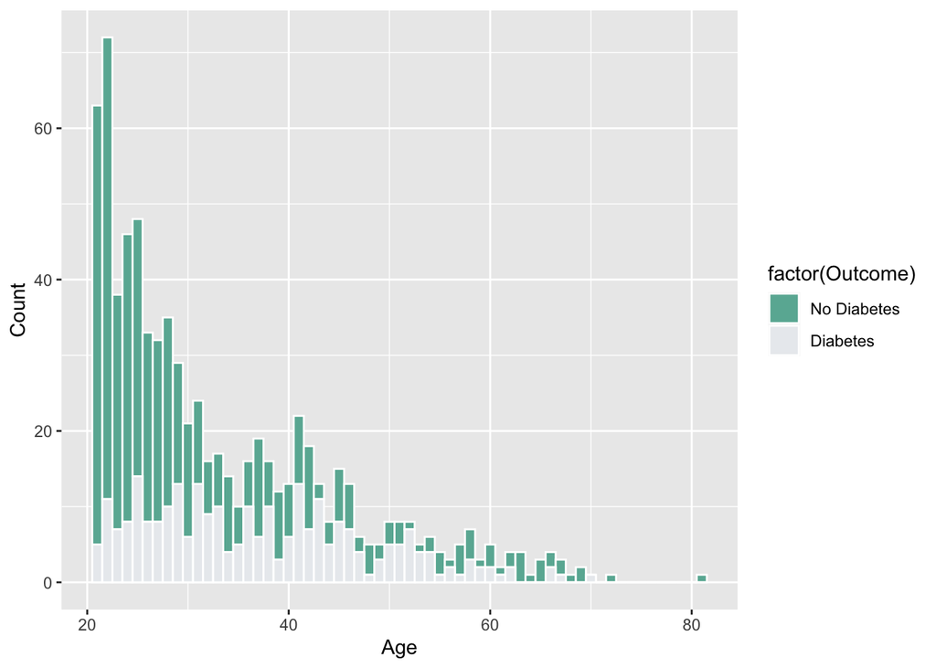

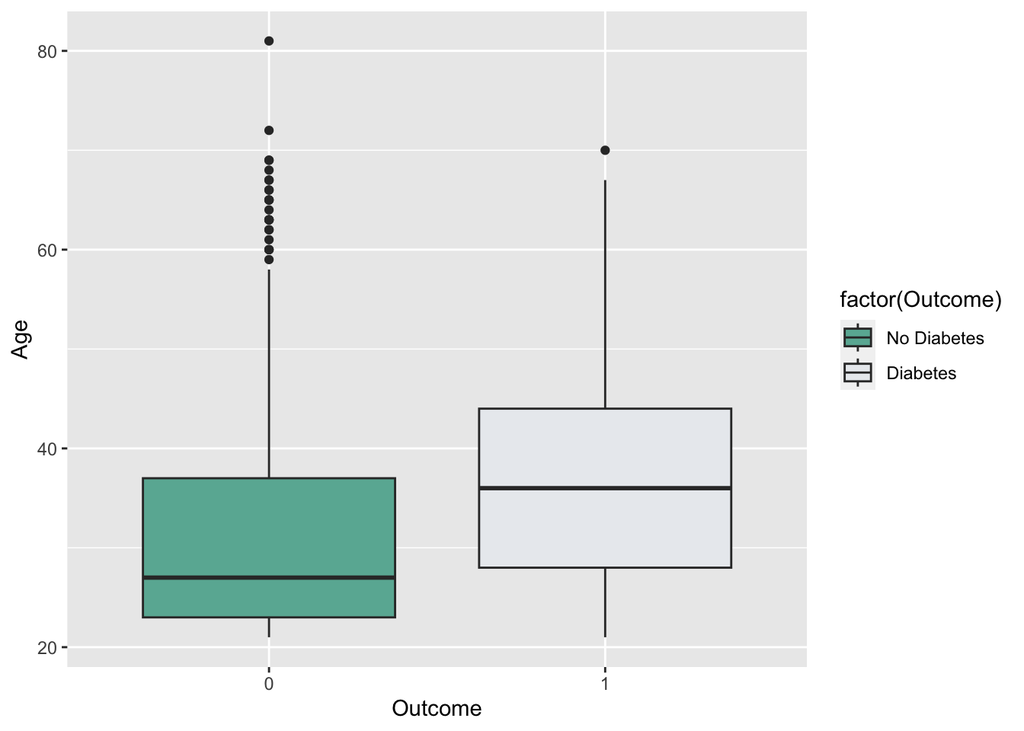

We have managed to reproduce the logistical regression model which have provided results which were practically identical with some insignificant differences when it comes to the results of the coefficients. However we were not able to obtain the same confusion matrix with accuracy score of 0.87 vs. 0.84 but this may have been contributed to the fact that the prediction on the user defined data was also inconsistent.

```
##
## Logistic Regression Model Summary:
```

```
##
## Call:
## glm(formula = Outcome ~ ., family = binomial(), data = train)
##
## Deviance Residuals:
##     Min       1Q   Median       3Q      Max
## -2.5611  -0.7417  -0.4268   0.7800   2.8242
##
## Coefficients:
##                            Estimate Std. Error z value Pr(>|z|)
## (Intercept)              -8.4541002  0.7658620 -11.039  < 2e-16 ***
## Pregnancies               0.1170079  0.0332566   3.518 0.000434 ***
## Glucose                   0.0333169  0.0038158   8.731  < 2e-16 ***
## BloodPressure            -0.0129974  0.0054283  -2.394 0.016649 *
## SkinThickness             0.0008438  0.0071562   0.118 0.906134
## Insulin                  -0.0012033  0.0009417  -1.278 0.201320
## BMI                       0.0981078  0.0162696   6.030 1.64e-09 ***
## DiabetesPedigreeFunction  0.9929868  0.3144512   3.158 0.001589 **
## Age                       0.0147697  0.0096549   1.530 0.126075
## ---
## Signif. codes:  0 '***' 0.001 '**' 0.01 '*' 0.05 '.' 0.1 ' ' 1
##
## (Dispersion parameter for binomial family taken to be 1)
##
##     Null deviance: 898.27  on 691  degrees of freedom
## Residual deviance: 665.78  on 683  degrees of freedom
## AIC: 683.78
##
## Number of Fisher Scoring iterations: 5
```

```
##
## Probit Regression Model Summary:
```

```
##
## Call:
## glm(formula = Outcome ~ ., family = binomial(link = "probit"),
##     data = train)
##
## Deviance Residuals:
##     Min       1Q   Median       3Q      Max
## -2.5667  -0.7626  -0.4194   0.8068   2.9462
##
## Coefficients:
##                            Estimate Std. Error z value Pr(>|z|)
## (Intercept)              -4.9048490  0.4168478 -11.767  < 2e-16 ***
## Pregnancies               0.0695056  0.0193494   3.592 0.000328 ***
## Glucose                   0.0188636  0.0021429   8.803  < 2e-16 ***
## BloodPressure            -0.0081265  0.0031605  -2.571 0.010133 *
## SkinThickness             0.0014568  0.0041800   0.349 0.727454
## Insulin                  -0.0007645  0.0005549  -1.378 0.168233
## BMI                       0.0582847  0.0092578   6.296 3.06e-10 ***
## DiabetesPedigreeFunction  0.5219176  0.1797772   2.903 0.003694 **
## Age                       0.0098757  0.0056900   1.736 0.082631 .
## ---
## Signif. codes:  0 '***' 0.001 '**' 0.01 '*' 0.05 '.' 0.1 ' ' 1
##
## (Dispersion parameter for binomial family taken to be 1)
##
##     Null deviance: 898.27  on 691  degrees of freedom
## Residual deviance: 667.21  on 683  degrees of freedom
## AIC: 685.21
##
## Number of Fisher Scoring iterations: 5
```

```
##
## Confusion Matrix:
```

```
##
## predicted_classes  0  1
##                 0 48  8
##                 1  4 16
```

```
##
## Accuracy: 0.8421053
```

## References:

- Dataset: https://www.kaggle.com/datasets/kandij/diabetes-dataset
- Original Code File used: https://www.kaggle.com/code/sujithmandala/easy-diabetics-prediction-logistic-regression

Libraries Used: “gplots: 3.1.3” “glmnet: 4.1.7” “Matrix: 1.5.4.1” “caret: 6.0.94” “lattice: 0.21.8” “lubridate: 1.9.2” “forcats: 1.0.0” “stringr: 1.5.0” “dplyr: 1.1.2” “purrr: 1.0.1” “readr: 2.1.4” “tidyr: 1.3.0” “tibble: 3.2.1” “ggplot2: 3.4.2” “tidyverse: 2.0.0” “stats: 4.3.1” “graphics: 4.3.1” “grDevices: 4.3.1” “utils: 4.3.1” “datasets: 4.3.1” “methods: 4.3.1” “base: 4.3.1”